# Final project

Richard Smeltzer

# Guided Question and Introduction

Was a 2019 MLB player’s batting ability affected by his age? I will be taking a look at several different batting statistics compared to each player’s age, to see if there was any correlation apparent between the two.

To be more specific, I will be looking at each team in the American League East division, meaning I will be looking at the Baltimore Orioles, Boston Red Sox, New York Yankees, Tampa Bay Rays, and Toronto Blue Jays. I will be looking at their players’ total plate appearances, hits, home runs, runs batted in (RBIs), stolen bases, on-base percentage (OBP), and weighted on-base plus slugging (OPS+) that they accumulated in the 2019 MLB season. I will be comparing all of these values to each players’ age, to see if that has any effect on how well they performed. Each case will be an individual player.

# Importing data

For this project, I will be using data from baseball-reference.com for each of these teams. From there, I can manipulate their tables and get the data I want in the form of .csv data. From there, I can use the “readr” package to copy and paste the data from the website, and read it into R as .csv data. In order to prevent confusion when using the data further on, I had to change the name of “OPS+” to “OPSplus.”

#### Reading libraries to use

```r
library(mosaic)
library(tidyverse)
library(mosaicData)
library(ggplot2)
library(DataComputing)
library(lubridate)
library(readr)
```

#### Inputting data from Baltimore Orioles

```r
Orioles <-
  read_csv("Age,PA,H,HR,RBI,SB,OBP,OPSplus
,,,,,,,
25,341,76,13,44,3,.321,95
33,352,55,12,36,0,.276,60
28,714,176,24,73,40,.339,109
24,309,59,6,23,10,.260,54
25,413,86,12,46,0,.306,81
26,392,86,13,53,5,.297,86
27,361,74,10,35,3,.286,76
27,679,175,35,97,1,.364,135
25,599,132,31,90,1,.311,101
26,550,160,12,51,4,.329,98
24,405,99,20,59,1,.297,101
24,198,35,8,20,0,.333,94
25,142,30,4,15,1,.317,85
28,135,24,2,6,3,.304,74
29,112,21,4,9,4,.261,61
29,108,22,2,11,4,.269,59
23,75,21,4,13,2,.373,147
24,74,6,0,4,1,.181,-8
28,74,15,1,5,0,.247,39
31,67,13,0,3,0,.269,39
27,34,8,0,2,1,.324,69
33,31,5,0,3,0,.226,33
25,4,0,0,0,0,.250,-22
25,1,0,0,0,0,.000,-100
25,4,0,0,0,0,.000,-100
29,4,0,0,0,0,.000,-100
32,3,0,0,0,0,.000,-100
26,3,1,0,0,0,1.000,439
25,2,0,0,0,0,.000,-100
26,2,0,0,0,0,.000,-100
30,1,0,0,0,0,.000,-100
26,0,0,0,0,0,,
27,0,0,0,0,0,,
32,0,0,0,0,0,,
28,0,0,0,0,0,,
29,0,0,0,0,0,,
24,0,0,0,0,0,,
25,0,0,0,0,0,,
27,0,0,0,0,0,,
27,0,0,0,0,0,,
27,0,0,0,0,0,,
27,0,0,0,0,0,,
30,0,0,0,0,0,,
25,0,0,0,0,0,,
25,0,0,0,0,0,,
26,0,0,0,0,0,,
28,0,0,0,0,0,,
26,0,0,0,0,0,,
31,0,0,0,0,0,,
24,0,0,0,0,0,,
29,0,0,0,0,0,,
24,0,0,0,0,0,,
28,0,0,0,0,0,,
31,0,0,0,0,0,,
24,0,0,0,0,0,,
24,0,0,0,0,0,,
29,0,0,0,0,0,,
23,0,0,0,0,0,,")
```

#### Inputting data from Boston Red Sox

```r
RedSox <-
  read_csv("Age,PA,H,HR,RBI,SB,OBP,OPSplus
,,,,,,,
28,521,133,23,72,4,.320,103
33,335,75,19,58,1,.328,112
31,295,77,3,31,1,.369,101
26,698,190,33,117,4,.384,140
22,702,201,32,115,8,.361,133
24,615,144,13,68,10,.343,100
29,567,111,21,62,8,.317,90
26,706,176,29,80,16,.391,135
31,657,175,36,105,2,.383,140
23,382,88,18,58,2,.322,96
30,191,33,5,19,0,.251,42
32,174,38,2,20,5,.243,42
25,157,31,6,16,2,.274,68
26,155,37,2,11,1,.279,60
36,99,16,1,9,0,.245,32
31,57,7,0,2,1,.218,21
27,51,7,1,5,1,.255,37
27,29,6,1,4,0,.310,80
25,22,4,0,1,1,.273,49
35,21,2,0,1,0,.143,-34
29,18,2,0,2,1,.278,14
26,9,0,0,0,0,.000,-100
30,6,0,0,0,0,.000,-100
29,2,0,0,0,0,.000,-100
33,2,1,0,1,0,.500,163
30,1,0,0,0,0,.000,-100
28,1,0,0,0,0,.000,-100
29,1,0,0,0,0,.000,-100
30,1,0,0,0,0,.000,-100
34,0,0,0,0,0,,
26,0,0,0,0,0,,
30,0,0,0,0,0,,
26,0,0,0,0,0,,
26,0,0,0,0,0,,
28,0,0,0,0,0,,
32,0,0,0,0,0,,
30,0,0,0,0,0,,
24,0,0,0,0,0,,
25,0,0,0,0,0,,
30,0,0,0,0,0,,
22,0,0,0,0,0,,
31,0,0,0,0,0,,
25,0,0,0,0,0,,
30,0,0,0,0,0,,
31,0,0,0,0,0,,
29,0,0,0,0,0,,
31,0,0,0,0,0,,")
```

#### Inputting data from New York Yankees

```r
Yankees <-
  read_csv("Age,PA,H,HR,RBI,SB,OBP,OPSplus
,,,,,,,
26,446,92,34,77,0,.316,119
28,510,113,21,62,0,.378,124
30,655,197,26,102,5,.375,136
29,344,77,16,61,2,.276,87
27,476,139,21,74,1,.355,133
28,296,72,13,47,6,.361,128
35,550,123,28,74,10,.325,117
27,447,103,27,55,3,.381,143
36,197,44,13,37,0,.325,123
22,604,152,38,90,5,.337,128
32,269,68,11,32,9,.364,127
29,255,52,12,36,1,.325,103
24,246,60,12,38,1,.317,111
30,240,64,8,35,1,.310,97
26,163,37,12,25,0,.350,137
24,108,23,2,11,7,.330,86
36,75,11,1,5,0,.320,55
29,72,17,3,13,0,.403,138
23,69,16,3,12,4,.294,92
29,57,12,3,11,0,.211,72
24,49,6,0,1,0,.143,-26
26,41,6,1,1,0,.293,50
27,37,7,0,3,0,.324,73
34,13,2,1,1,0,.308,121
30,8,0,0,1,0,.000,-100
26,8,0,0,0,0,.000,-100
36,4,0,0,0,0,.000,-100
38,3,0,0,0,0,.000,-100
27,1,0,0,0,0,.000,-100
30,1,0,0,0,0,.000,-100
28,1,0,0,0,0,.000,-100
31,0,0,0,0,0,,
26,0,0,0,0,0,,
24,0,0,0,0,0,,
31,0,0,0,0,0,,
33,0,0,0,0,0,,
31,0,0,0,0,0,,
29,0,0,0,0,0,,
31,0,0,0,0,0,,
26,0,0,0,0,0,,
27,0,0,0,0,0,,
24,0,0,0,0,0,,
28,0,0,0,0,0,,
31,0,0,0,0,0,,
24,0,0,0,0,0,,
29,0,0,0,0,0,,
27,0,0,0,0,0,,
24,0,0,0,0,0,,
26,0,0,0,0,0,,
27,0,0,0,0,0,,
25,0,0,0,0,0,,
24,0,0,0,0,0,,
25,0,0,0,0,0,,
33,0,0,0,0,0,,")
```

#### Inputting data from Tampa Bay Rays

```r
Rays <-
  read_csv("Age,PA,H,HR,RBI,SB,OBP,OPSplus
,,,,,,,
28,289,44,9,32,0,.232,44
28,487,107,19,63,2,.363,119
24,327,80,17,51,5,.336,124
23,584,135,20,52,4,.317,95
27,346,82,14,38,2,.340,116
31,654,155,21,68,25,.369,119
29,480,102,14,55,19,.278,79
28,530,138,20,72,10,.332,111
24,591,154,33,89,12,.364,143
30,365,86,16,67,0,.323,107
29,263,55,3,19,8,.293,70
25,237,44,2,19,2,.312,66
28,231,46,5,20,2,.306,79
23,170,40,7,19,0,.325,106
28,169,37,1,12,0,.343,83
25,142,36,6,16,1,.319,106
33,119,29,3,10,2,.328,96
29,107,24,4,16,0,.336,103
24,57,11,2,7,0,.304,83
26,55,10,0,2,0,.345,83
39,17,1,0,0,0,.059,-68
24,14,3,0,0,0,.214,16
24,12,1,0,0,0,.083,-36
24,6,1,0,0,0,.167,-9
29,5,2,0,1,0,.400,163
29,4,1,0,0,0,.250,151
23,11,2,1,1,0,.273,101
25,3,0,0,0,0,.000,-100
25,2,0,0,0,0,.000,-100
25,2,0,0,0,0,.000,-100
35,2,0,0,0,0,.000,-100
25,1,0,0,0,0,.000,-100
28,1,0,0,0,0,.000,-100
29,1,0,0,0,0,.000,-100
32,1,1,0,1,0,1.000,444
26,0,0,0,0,0,,
29,0,0,0,0,0,,
25,0,0,0,0,0,,
25,0,0,0,0,0,,
25,0,0,0,0,0,,
25,0,0,0,0,0,,
28,0,0,0,0,0,,
26,0,0,0,0,0,,
32,0,0,0,0,0,,
25,0,0,0,0,0,,
26,0,0,0,0,0,,
29,0,0,0,0,0,,
27,0,0,0,0,0,,
25,0,0,0,0,0,,
28,0,0,0,0,0,,
25,0,0,0,0,0,,
30,0,0,0,0,0,,
27,0,0,0,0,0,,
26,0,0,0,0,0,,
28,0,0,0,0,0,,
24,0,0,0,0,0,,
29,0,0,0,0,0,,")
```

#### Inputting data from Toronto Blue Jays

```r
BlueJays <-
  read_csv("Age,PA,H,HR,RBI,SB,OBP,OPSplus
,,,,,,,
24,384,72,13,43,0,.279,70
32,500,86,22,61,0,.342,101
24,430,83,16,48,14,.364,113
29,473,120,18,54,4,.299,96
20,514,126,15,69,0,.339,106
25,343,87,20,50,6,.327,127
26,464,96,26,65,6,.306,105
27,628,136,31,80,2,.280,93
24,409,84,21,54,1,.293,95
26,447,91,15,41,0,.262,70
33,323,86,10,30,6,.363,123
24,276,54,12,28,0,.274,83
21,212,61,11,21,4,.358,144
28,129,18,2,9,1,.205,18
25,107,15,6,12,1,.271,72
24,105,29,5,11,0,.346,130
27,95,15,2,6,3,.266,44
23,80,18,0,4,0,.273,60
26,48,7,0,4,1,.229,9
26,43,3,0,2,0,.163,-19
24,30,5,1,1,2,.233,39
30,17,1,0,1,0,.059,-67
27,15,4,1,3,0,.267,106
29,2,0,0,0,0,.000,-100
25,3,0,0,0,0,.333,4
25,3,2,0,0,0,.667,262
35,3,0,0,0,0,.000,-100
26,2,0,0,0,0,.000,-100
28,2,0,0,0,0,.000,-100
19,1,0,0,0,0,.000,-100
23,1,0,0,0,0,.000,-100
23,1,0,0,0,0,.000,-100
29,1,0,0,0,0,.000,-100
29,0,0,0,0,0,,
27,0,0,0,0,0,,
33,0,0,0,0,0,,
29,0,0,0,0,0,,
30,0,0,0,0,0,,
33,0,0,0,0,0,,
28,0,0,0,0,0,,
34,0,0,0,0,0,,
31,0,0,0,0,0,,
31,0,0,0,0,0,,
27,0,0,0,0,0,,
32,0,0,0,0,0,,
22,0,0,0,0,0,,
27,0,0,0,0,0,,
27,0,0,0,0,0,,
27,0,0,0,0,0,,
29,0,0,0,0,0,,
32,0,0,0,0,0,,
29,0,0,0,0,0,,
31,0,0,0,0,0,,
26,0,0,0,0,0,,
32,0,0,0,0,0,,
24,0,0,0,0,0,,
35,0,0,0,0,0,,
28,0,0,0,0,0,,
25,0,0,0,0,0,,
25,0,0,0,0,0,,
26,0,0,0,0,0,,")
```

# Inspecting Data

In this part of the analysis, I will be doing do introductory inspection of each data set. For this, I will be using nrow to determine the number of cases in each data set, sorting each data set by descending age, and checking the top 10. This will tell me the 10 oldest players on each team, as well as the total number of players included for each team.

#### Inspecting Orioles

```r
nrow(Orioles)
```

```
[1] 59
```

```r
Orioles %>%
  arrange(desc(Age)) %>%
  head(10)
```

| Age | PA | H | HR | RBI | SB | OBP | OPSplus |
| --- | --- | --- | --- | --- | --- | --- | --- |
| 33 | 352 | 55 | 12 | 36 | 0 | 0.276 | 60 |
| 33 | 31 | 5 | 0 | 3 | 0 | 0.226 | 33 |
| 32 | 3 | 0 | 0 | 0 | 0 | 0.000 | -100 |
| 32 | 0 | 0 | 0 | 0 | 0 | NA | NA |
| 31 | 67 | 13 | 0 | 3 | 0 | 0.269 | 39 |
| 31 | 0 | 0 | 0 | 0 | 0 | NA | NA |
| 31 | 0 | 0 | 0 | 0 | 0 | NA | NA |
| 30 | 1 | 0 | 0 | 0 | 0 | 0.000 | -100 |
| 30 | 0 | 0 | 0 | 0 | 0 | NA | NA |
| 29 | 112 | 21 | 4 | 9 | 4 | 0.261 | 61 |

#### Inspecting Red Sox

```r
nrow(RedSox)
```

```
[1] 48
```

```r
RedSox %>%
  arrange(desc(Age)) %>%
  head(10)
```

| Age | PA | H | HR | RBI | SB | OBP | OPSplus |
| --- | --- | --- | --- | --- | --- | --- | --- |
| 36 | 99 | 16 | 1 | 9 | 0 | 0.245 | 32 |
| 35 | 21 | 2 | 0 | 1 | 0 | 0.143 | -34 |
| 34 | 0 | 0 | 0 | 0 | 0 | NA | NA |
| 33 | 335 | 75 | 19 | 58 | 1 | 0.328 | 112 |
| 33 | 2 | 1 | 0 | 1 | 0 | 0.500 | 163 |
| 32 | 174 | 38 | 2 | 20 | 5 | 0.243 | 42 |
| 32 | 0 | 0 | 0 | 0 | 0 | NA | NA |
| 31 | 295 | 77 | 3 | 31 | 1 | 0.369 | 101 |
| 31 | 657 | 175 | 36 | 105 | 2 | 0.383 | 140 |
| 31 | 57 | 7 | 0 | 2 | 1 | 0.218 | 21 |

#### Inspecting Yankees

```r
nrow(Yankees)
```

```
[1] 55
```

```r
Yankees %>%
  arrange(desc(Age)) %>%
  head(10)
```

| Age | PA | H | HR | RBI | SB | OBP | OPSplus |
| --- | --- | --- | --- | --- | --- | --- | --- |
| 38 | 3 | 0 | 0 | 0 | 0 | 0.000 | -100 |
| 36 | 197 | 44 | 13 | 37 | 0 | 0.325 | 123 |
| 36 | 75 | 11 | 1 | 5 | 0 | 0.320 | 55 |
| 36 | 4 | 0 | 0 | 0 | 0 | 0.000 | -100 |
| 35 | 550 | 123 | 28 | 74 | 10 | 0.325 | 117 |
| 34 | 13 | 2 | 1 | 1 | 0 | 0.308 | 121 |
| 33 | 0 | 0 | 0 | 0 | 0 | NA | NA |
| 33 | 0 | 0 | 0 | 0 | 0 | NA | NA |
| 32 | 269 | 68 | 11 | 32 | 9 | 0.364 | 127 |
| 31 | 0 | 0 | 0 | 0 | 0 | NA | NA |

#### Inspecting Rays

```r
nrow(Rays)
```

```
[1] 58
```

```r
Rays %>%
  arrange(desc(Age)) %>%
  head(10)
```

| Age | PA | H | HR | RBI | SB | OBP | OPSplus |
| --- | --- | --- | --- | --- | --- | --- | --- |
| 39 | 17 | 1 | 0 | 0 | 0 | 0.059 | -68 |
| 35 | 2 | 0 | 0 | 0 | 0 | 0.000 | -100 |
| 33 | 119 | 29 | 3 | 10 | 2 | 0.328 | 96 |
| 32 | 1 | 1 | 0 | 1 | 0 | 1.000 | 444 |
| 32 | 0 | 0 | 0 | 0 | 0 | NA | NA |
| 31 | 654 | 155 | 21 | 68 | 25 | 0.369 | 119 |
| 30 | 365 | 86 | 16 | 67 | 0 | 0.323 | 107 |
| 30 | 0 | 0 | 0 | 0 | 0 | NA | NA |
| 29 | 480 | 102 | 14 | 55 | 19 | 0.278 | 79 |
| 29 | 263 | 55 | 3 | 19 | 8 | 0.293 | 70 |

#### Inspecting Blue Jays

```r
nrow(BlueJays)
```

```
[1] 62
```

```r
BlueJays %>%
  arrange(desc(Age)) %>%
  head(10)
```

| Age | PA | H | HR | RBI | SB | OBP | OPSplus |
| --- | --- | --- | --- | --- | --- | --- | --- |
| 35 | 3 | 0 | 0 | 0 | 0 | 0.000 | -100 |
| 35 | 0 | 0 | 0 | 0 | 0 | NA | NA |
| 34 | 0 | 0 | 0 | 0 | 0 | NA | NA |
| 33 | 323 | 86 | 10 | 30 | 6 | 0.363 | 123 |
| 33 | 0 | 0 | 0 | 0 | 0 | NA | NA |
| 33 | 0 | 0 | 0 | 0 | 0 | NA | NA |
| 32 | 500 | 86 | 22 | 61 | 0 | 0.342 | 101 |
| 32 | 0 | 0 | 0 | 0 | 0 | NA | NA |
| 32 | 0 | 0 | 0 | 0 | 0 | NA | NA |
| 32 | 0 | 0 | 0 | 0 | 0 | NA | NA |

As we can see from the introductory analysis, every team seems to generally have a similar number of players, as well as a similar range of ages. There will not be too many outlier for this project, which will make it much easier to visualize the data later on.

# Data Wrangling

In order to make further judgements of my data, I need to do some data wrangling. To do this, I will be joining all five data sets together into one big set. I will do this using the rbind function, as it lets me merge them all in one step. I will be adding a variable called “Team” that will represent each players’ team name. I will also be dropping any cases that have an “NA” value, as they will not help our study. Once I finish this, I will be creating two new data sets: one will show the averages of stats per team, while the other shows the average stats per age group.

#### Adding team name to each data set

```r
Orioles <-
  Orioles %>%
  mutate(Team = "Orioles")
RedSox <-
  RedSox %>%
  mutate(Team = "Red Sox")
Yankees <-
  Yankees %>%
  mutate(Team = "Yankees")
Rays <-
  Rays %>%
  mutate(Team = "Rays")
BlueJays <-
  BlueJays %>%
  mutate(Team = "Blue Jays")
```

#### Joining the teams together

```r
allTeams <-
  rbind(Orioles, RedSox, Yankees, Rays, BlueJays)
```

#### Dropping any cases with NA

```r
allTeams <-
  allTeams[complete.cases(allTeams), ]
allTeams <-
  allTeams %>%
  filter(PA >= 30)
allTeams
```

| Age | PA | H | HR | RBI | SB | OBP | OPSplus | Team |
| --- | --- | --- | --- | --- | --- | --- | --- | --- |
| 25 | 341 | 76 | 13 | 44 | 3 | 0.321 | 95 | Orioles |
| 33 | 352 | 55 | 12 | 36 | 0 | 0.276 | 60 | Orioles |
| 28 | 714 | 176 | 24 | 73 | 40 | 0.339 | 109 | Orioles |
| 24 | 309 | 59 | 6 | 23 | 10 | 0.260 | 54 | Orioles |
| 25 | 413 | 86 | 12 | 46 | 0 | 0.306 | 81 | Orioles |
| 26 | 392 | 86 | 13 | 53 | 5 | 0.297 | 86 | Orioles |
| 27 | 361 | 74 | 10 | 35 | 3 | 0.286 | 76 | Orioles |
| 27 | 679 | 175 | 35 | 97 | 1 | 0.364 | 135 | Orioles |
| 25 | 599 | 132 | 31 | 90 | 1 | 0.311 | 101 | Orioles |
| 26 | 550 | 160 | 12 | 51 | 4 | 0.329 | 98 | Orioles |

[output cut: 93 more lines]

After doing this, I now have a much cleaner data set than I had before. I needed to drop every case with an NA value, because they would end up negatively affecting the averages calculations. The only reason they would have had NA values in the first place is because those players did not record enough significant data to even be used in this analysis. In addition to this, I am also filtering out players with less than 30 plate appearances. Any player with less than this did not accumulate enough significant data for our analysis.

#### Finding average of each stat per team

```r
teamsAvg <-
  allTeams %>%
  group_by(Team) %>%
  summarise(avgAge = mean(Age), avgHits = mean(H), avgPA = mean(PA), avgHR = mean(HR), avgRBI = mean(RBI), avgSB = mean(SB), avgOBP = mean(OBP), avgOPSplus = mean(OPSplus))
teamsAvg
```

| Team | avgAge | avgHits | avgPA | avgHR | avgRBI | avgSB | avgOBP | avgOPSplus |
| --- | --- | --- | --- | --- | --- | --- | --- | --- |
| Blue Jays | 25.61905 | 61.52381 | 287.6190 | 11.714286 | 33.00000 | 2.428571 | 0.2891429 | 79.95238 |
| Orioles | 26.86364 | 62.63636 | 280.2273 | 9.681818 | 31.72727 | 3.818182 | 0.2950000 | 76.72727 |
| Rays | 27.10000 | 70.75000 | 310.1500 | 10.800000 | 36.35000 | 4.700000 | 0.3232500 | 96.60000 |
| Red Sox | 28.23529 | 90.52941 | 374.2353 | 14.352941 | 49.88235 | 3.882353 | 0.3107647 | 85.41176 |
| Yankees | 28.13043 | 64.82609 | 269.8261 | 13.260870 | 39.21739 | 2.391304 | 0.3223043 | 102.30435 |

This shows me the average values of each stat for each team. Once again, it seems as though there is not too much variation between each team. Generally speaking however, it seems as though the teams with higher average ages tend to have better batting statistics to go with it. Because of this, we will now compare each stat to individual age group, since it seems to have the greatest effect.

#### Finding averages by ages

```r
agesAvg <-
  allTeams %>%
  group_by(Age) %>%
  summarise(avgHits = mean(H), avgPA = mean(PA), avgHR = mean(HR), avgRBI = mean(RBI), avgSB = mean(SB), avgOBP = mean(OBP), avgOPSplus = mean(OPSplus), count = n()) %>%
  filter(count >= 5)
agesAvg
```

| Age | avgHits | avgPA | avgHR | avgRBI | avgSB | avgOBP | avgOPSplus | count |
| --- | --- | --- | --- | --- | --- | --- | --- | --- |
| 23 | 53.00000 | 226.6667 | 8.666667 | 26.33333 | 2.000000 | 0.3173333 | 99.33333 | 6 |
| 24 | 59.05882 | 271.3529 | 10.647059 | 32.70588 | 3.764706 | 0.2939412 | 81.88235 | 17 |
| 25 | 59.66667 | 275.6667 | 11.111111 | 34.22222 | 1.888889 | 0.3064444 | 89.00000 | 9 |
| 26 | 76.23077 | 323.6923 | 13.615385 | 40.69231 | 2.846154 | 0.3033846 | 82.53846 | 13 |
| 27 | 74.60000 | 315.4000 | 14.100000 | 39.50000 | 1.700000 | 0.3175000 | 91.90000 | 10 |
| 28 | 76.91667 | 340.4167 | 11.666667 | 39.41667 | 5.666667 | 0.3108333 | 85.91667 | 12 |
| 29 | 55.72727 | 258.0000 | 9.090909 | 31.54545 | 4.545455 | 0.2970909 | 87.09091 | 11 |
| 31 | 85.40000 | 346.0000 | 12.000000 | 41.80000 | 5.800000 | 0.3216000 | 84.00000 | 5 |
| 33 | 50.00000 | 232.0000 | 8.800000 | 27.40000 | 1.800000 | 0.3042000 | 84.80000 | 5 |

This finally gives us the data set we will be working with when we do the final data visualization step. This will allow us to see the way in which age affects the player’s overall batting stats. Having the count variable also lets us leave out ages without significant data.

# Data Visualization

In this step, I will try to use several different types of graphs to showcase how these variables are affected by each other. Specifically, I will be looking at how OPS+ compares to these variables. OPS+ is a baseball statistic that essentially looks at how a player’s overall batting statistics compare to the rest of the league. An OPS+ value of 100 is considered a league-average hitter. This will make hitting ability easy to visualize in graphs.

#### Comparing team to OPS+

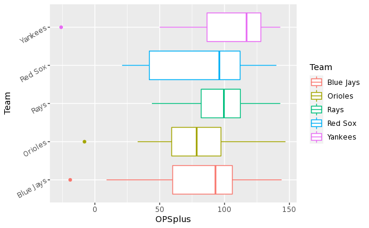

```r
allTeams %>%
  ggplot(aes(x = Team, y = OPSplus, color = Team)) +
  geom_boxplot() + theme(axis.text.y = element_text(angle = 30, hjust = 1)) +
  coord_flip()
```

As we can see from this chart, there is a bit of variation between each team’s OPS+ values. We can see the Yankees generally had the highest values, while the Orioles generally had the lowest. This makes sense, as we know the Yankees won the American League East division, while the Orioles finished in last place. Though as we saw earlier, this does not tell the whole story. The Yankees were also a generally older team than the Orioles, so next we will see how each age group specifically affected overall batting performance.

#### Comparing age to avg OPS+

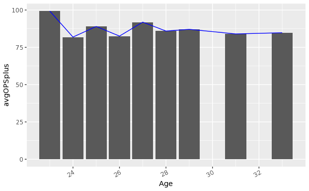

```r
agesAvg %>%
  ggplot(aes(x = Age, y = avgOPSplus), y_sc) +
  geom_bar(stat="identity") + theme(axis.text.x = element_text(angle = 30, hjust = 1)) + geom_line(color = "blue")
```

As we can generally see here, there is not much we can gather from this chart. The data values are too close together for us to make any assumptions. It doesn’t seem like there is much variation between the ages, so instead we will look at a box plot to see if we can learn anything else.

#### Box plot of age vs OPS+

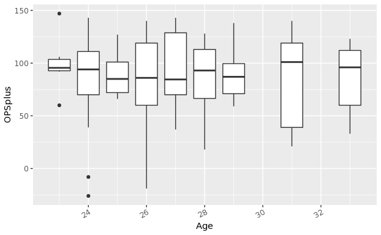

```r
allTeams %>%
  group_by(Age) %>%
  mutate(count = n()) %>%
  filter(count >= 5) %>%
  ggplot(aes(x = Age, y = OPSplus, group = Age)) +
  geom_boxplot() + theme(axis.text.x = element_text(angle = 30, hjust = 1))
```

Now we can see the information we really want. Grouping the general population by age and checking to see the OPS+ with respect to these groups allows us to see the differences going on here.

# Concluding analysis

It really isn’t fair to draw these conclusions based on the data we have visualized. Since there is extremely little variability between OPS+ and each player’s age, there is no way that we can make any comments based on this. Instead, we must assume that a player’s age has no effect on his hitting ability.